# 聚类算法---R的使用

## 1. 距离的计算和比较

```r
a<-matrix(runif(25),c(5,5))
a
```

A matrix: 5 × 5 of type dbl

| 0.5337121 | 0.30446719 | 0.6831820 | 0.6859444 | 0.8885003 |
| --- | --- | --- | --- | --- |
| 0.4985096 | 0.94237659 | 0.6431069 | 0.5336461 | 0.8917105 |
| 0.4542800 | 0.86759165 | 0.5216729 | 0.2585142 | 0.9727970 |
| 0.7470456 | 0.76076977 | 0.0377663 | 0.9404198 | 0.4532096 |
| 0.1220718 | 0.01864327 | 0.5766316 | 0.2528558 | 0.1510157 |

```r
# 显示曼哈顿距离
dist(a,"manhattan")
```

```
          1         2         3         4
2 0.8686955
3 1.3157925 0.5966669
4 2.0048177 1.8807581 2.0849870
5 1.9745878 2.3881317 2.0635550 2.8957235
```

```r
# 显示欧几里得距离
dist(a,p=2)
```

```
          1         2         3         4
2 0.6580112
3 0.7343748 0.3233695
4 0.9615198 0.9049510 1.0325959
5 0.9969681 1.2754919 1.2285978 1.3400691
```

```r
a<-matrix(runif(15),c(3,5))
# 显示曼哈顿距离
dist(a,"manhattan")
```

```
         1        2
2 1.992848
3 1.521071 2.312489
```

```r
dist(a,p=2)
```

```
          1         2
2 1.0303021
3 0.7912985 1.1334897
```

```r
a<-c(10,9,8)
b<-c(4,3,2)
c<-c(8,9,10)
```

### a,b之间的余弦相似性

#### 对于高维的文字向量，经常采用余弦相似性

```r
#a,b之间的余弦相似性
sum(a*b)/sqrt(sum(a^2)*sum(b^2))
```

0.984682118265774

```r
#a,c之间的余弦相似性
sum(a*c)/sqrt(sum(a^2)*sum(c^2))
```

0.983673469387755

```r
#b,c之间的余弦相似性
sum(b*c)/sqrt(sum(b^2)*sum(c^2))
```

0.937227558349351

```r
x=rbind(a,b,c)
x
```

A matrix: 3 × 3 of type dbl

| a | 10 | 9 | 8 |
| --- | --- | --- | --- |
| b | 4 | 3 | 2 |
| c | 8 | 9 | 10 |

```r
#a,b,c之间的欧几里得距离
dist(x,p=2)
dist(x)
```

```
          a         b
b 10.392305
c  2.828427 10.770330
```

```
          a         b
b 10.392305
c  2.828427 10.770330
```

## 2. 啤酒的系统聚类分析

### 2.1 读入数据

```r
####读入数据####
beer=read.table("C:/Users/bff/Desktop/me-ppt/beer_data.txt",header=T,sep=" ")
beer=as.matrix(beer)
beer
#注意beer为字符串格式
```

A matrix: 20 × 5 of type chr

| name | calories | sodium | alcohol | cost |
| --- | --- | --- | --- | --- |
| Budweiser | 144 | 15 | 4.7 | 0.43 |
| Schlitz | 151 | 19 | 4.9 | 0.43 |
| Lowenbrau | 157 | 15 | 0.9 | 0.48 |
| Kronenbourg | 170 | 7 | 5.2 | 0.73 |
| Heineken | 152 | 11 | 5.0 | 0.77 |
| Old_Milwaukee | 145 | 23 | 4.6 | 0.28 |
| Augsberger | 175 | 24 | 5.5 | 0.40 |
| Srohs_Bohemian_Style | 149 | 27 | 4.7 | 0.42 |
| Miller_Lite | 99 | 10 | 4.3 | 0.43 |
| Budweiser_Light | 113 | 8 | 3.7 | 0.40 |
| Coors | 140 | 18 | 4.6 | 0.44 |
| Coors_Light | 102 | 15 | 4.1 | 0.46 |
| Michelob_Light | 135 | 11 | 4.2 | 0.50 |
| Becks | 150 | 19 | 4.7 | 0.76 |
| Kirin | 149 | 6 | 5.0 | 0.79 |
| Pabst_Extra_Light | 68 | 15 | 2.3 | 0.38 |
| Hamms | 139 | 19 | 4.4 | 0.43 |
| Heilemans_Old_Style | 144 | 24 | 4.9 | 0.43 |
| Olympia_Goled_Light | 72 | 6 | 2.9 | 0.46 |
| Schlitz_Light | 97 | 7 | 4.2 | 0.47 |

```r
####描述分析####
#x=beer[,-1]
x=apply(beer[,2:5],2,as.numeric)
rownames(x)=beer[,1]
x
summary(x)
```

A matrix: 20 × 4 of type dbl

|  | calories | sodium | alcohol | cost |
| --- | --- | --- | --- | --- |
| Budweiser | 144 | 15 | 4.7 | 0.43 |
| Schlitz | 151 | 19 | 4.9 | 0.43 |
| Lowenbrau | 157 | 15 | 0.9 | 0.48 |
| Kronenbourg | 170 | 7 | 5.2 | 0.73 |
| Heineken | 152 | 11 | 5.0 | 0.77 |
| Old_Milwaukee | 145 | 23 | 4.6 | 0.28 |
| Augsberger | 175 | 24 | 5.5 | 0.40 |
| Srohs_Bohemian_Style | 149 | 27 | 4.7 | 0.42 |
| Miller_Lite | 99 | 10 | 4.3 | 0.43 |
| Budweiser_Light | 113 | 8 | 3.7 | 0.40 |
| Coors | 140 | 18 | 4.6 | 0.44 |
| Coors_Light | 102 | 15 | 4.1 | 0.46 |
| Michelob_Light | 135 | 11 | 4.2 | 0.50 |
| Becks | 150 | 19 | 4.7 | 0.76 |
| Kirin | 149 | 6 | 5.0 | 0.79 |
| Pabst_Extra_Light | 68 | 15 | 2.3 | 0.38 |
| Hamms | 139 | 19 | 4.4 | 0.43 |
| Heilemans_Old_Style | 144 | 24 | 4.9 | 0.43 |
| Olympia_Goled_Light | 72 | 6 | 2.9 | 0.46 |
| Schlitz_Light | 97 | 7 | 4.2 | 0.47 |

```
    calories         sodium         alcohol           cost
 Min.   : 68.0   Min.   : 6.00   Min.   :0.900   Min.   :0.2800
 1st Qu.:110.2   1st Qu.: 9.50   1st Qu.:4.175   1st Qu.:0.4275
 Median :144.0   Median :15.00   Median :4.600   Median :0.4350
 Mean   :132.6   Mean   :14.95   Mean   :4.240   Mean   :0.4945
 3rd Qu.:150.2   3rd Qu.:19.00   3rd Qu.:4.900   3rd Qu.:0.4850
 Max.   :175.0   Max.   :27.00   Max.   :5.500   Max.   :0.7900
```

```r
#因为不同变量取值差别较大，故将数据标准化
xstd=scale(x)
summary(xstd)
```

```
    calories           sodium             alcohol              cost
 Min.   :-2.1315   Min.   :-1.359919   Min.   :-3.07007   Min.   :-1.48076
 1st Qu.:-0.7364   1st Qu.:-0.828107   1st Qu.:-0.05975   1st Qu.:-0.46252
 Median : 0.3781   Median : 0.007597   Median : 0.33091   Median :-0.41075
 Mean   : 0.0000   Mean   : 0.000000   Mean   : 0.00000   Mean   : 0.00000
 3rd Qu.: 0.5845   3rd Qu.: 0.615382   3rd Qu.: 0.60666   3rd Qu.:-0.06558
 Max.   : 1.4017   Max.   : 1.830953   Max.   : 1.15817   Max.   : 2.03992
```

### 2.2 计算欧氏距离

```r
d=dist(xstd)
```

### 2.3 用不同联接方法系统聚类

```r
hc1=hclust(d,"single")  #最短距离法
hc2=hclust(d,"complete")#最长距离法，R中默认的联接方法
hc3=hclust(d,"ward.D")  #ward法 即离差平方和的方法，反映样本之间的差异程度
hc4=hclust(d,"centroid")#重心法
```

### 2.4 绘制谱系图

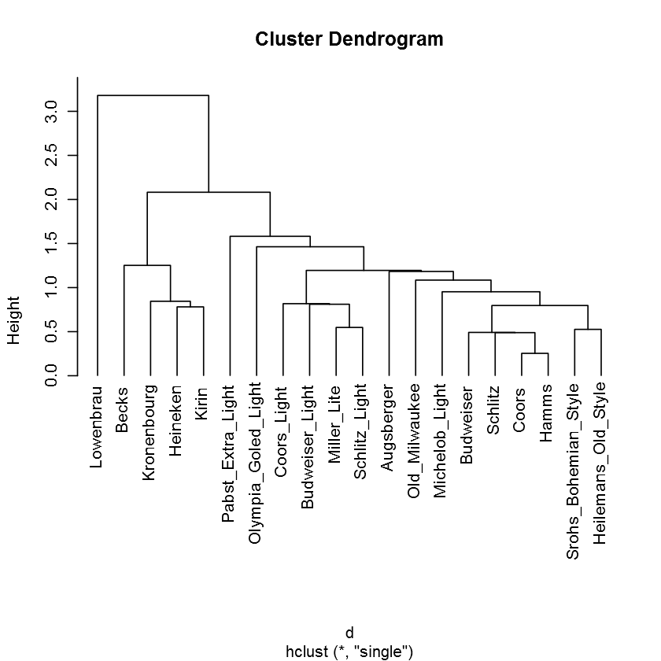

```r
####绘制谱四种联结方法得到的谱系图####
par(mfrow=c(1,1))#设置画布，如可以绘制2*2的组图。
#par(family='STKaiti')#设置字体
plot(hc1,hang=-1)#最短距离法的谱系图
```

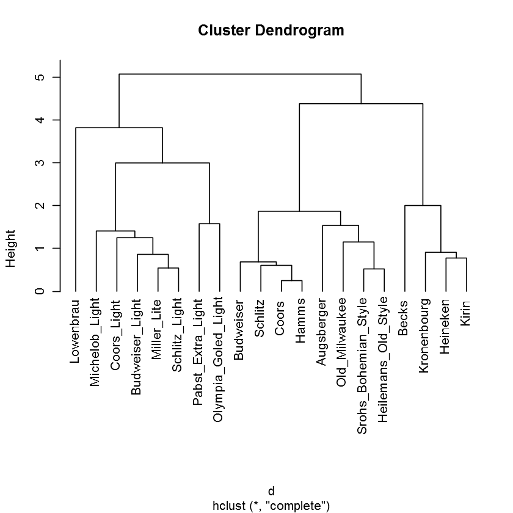

```r
plot(hc2,hang=-1)#最长距离法的谱系图
```

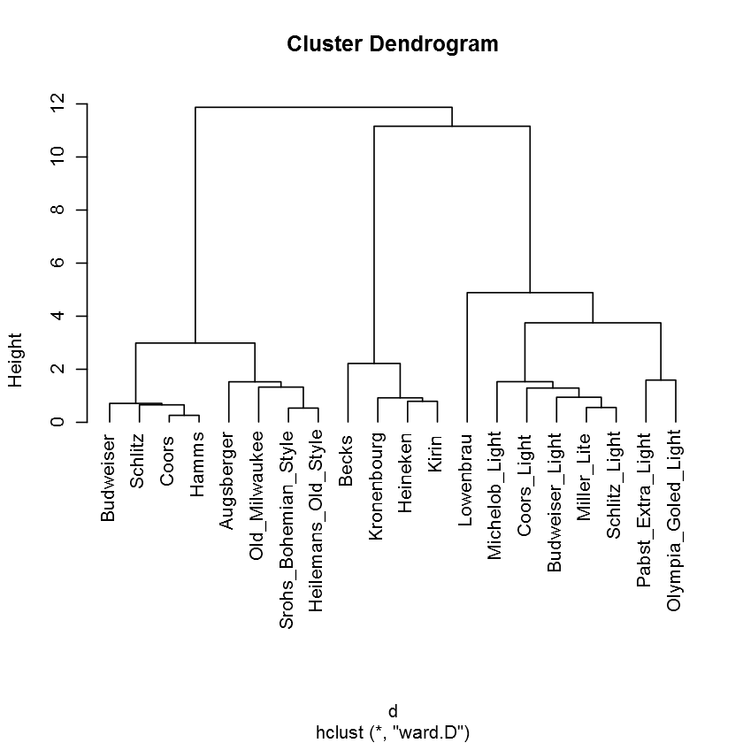

```r
plot(hc3,hang=-1)#ward法的谱系图
```

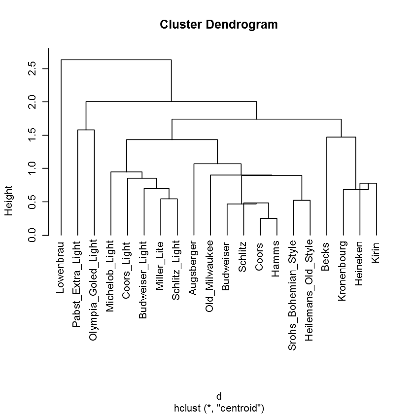

```r
plot(hc4,hang=-1)#重心法的谱系图
```

#### 解读和分析： 使用系统聚类方法时，点与点之间的距离用欧式距离，类与类之间的连接使用了四种不同的

距离定义，得到的结果也不同，接下来要结合具体的问题进行分析。

## 3. 啤酒的k-mean聚类分析

```r
cl=kmeans(xstd,3,20) # 聚为3类，最大迭代次数20
```

### 3.1 聚类结果展示

```r
cl # 展示K均值聚类的主要结果
```

```
K-means clustering with 3 clusters of sizes 8, 8, 4

Cluster means:
    calories     sodium    alcohol       cost
1  0.5225583  0.9382683  0.5032520 -0.6005866
2 -0.8973473 -0.6191811 -0.8410513 -0.3244548
3  0.7495781 -0.6381744  0.6755986  1.8500829

Clustering vector:
           Budweiser              Schlitz            Lowenbrau
                   1                    1                    2
         Kronenbourg             Heineken        Old_Milwaukee
                   3                    3                    1
          Augsberger Srohs_Bohemian_Style          Miller_Lite
                   1                    1                    2
     Budweiser_Light                Coors          Coors_Light
                   2                    1                    2
      Michelob_Light                Becks                Kirin
                   2                    3                    3
   Pabst_Extra_Light                Hamms  Heilemans_Old_Style
                   2                    1                    1
 Olympia_Goled_Light        Schlitz_Light
                   2                    2

Within cluster sum of squares by cluster:
[1]  5.148408 18.372094  2.936904
 (between_SS / total_SS =  65.2 %)

Available components:

[1] "cluster"      "centers"      "totss"        "withinss"     "tot.withinss"
[6] "betweenss"    "size"         "iter"         "ifault"
```

```r
#### 也可以单独展示部分结果####
cl$cluster #展示每个样本观测属于哪一类
```

**Budweiser**

1

**Schlitz**

1

**Lowenbrau**

2

**Kronenbourg**

3

**Heineken**

3

**Old_Milwaukee**

1

**Augsberger**

1

**Srohs_Bohemian_Style**

1

**Miller_Lite**

2

**Budweiser_Light**

2

**Coors**

1

**Coors_Light**

2

**Michelob_Light**

2

**Becks**

3

**Kirin**

3

**Pabst_Extra_Light**

2

**Hamms**

1

**Heilemans_Old_Style**

1

**Olympia_Goled_Light**

2

**Schlitz_Light**

2

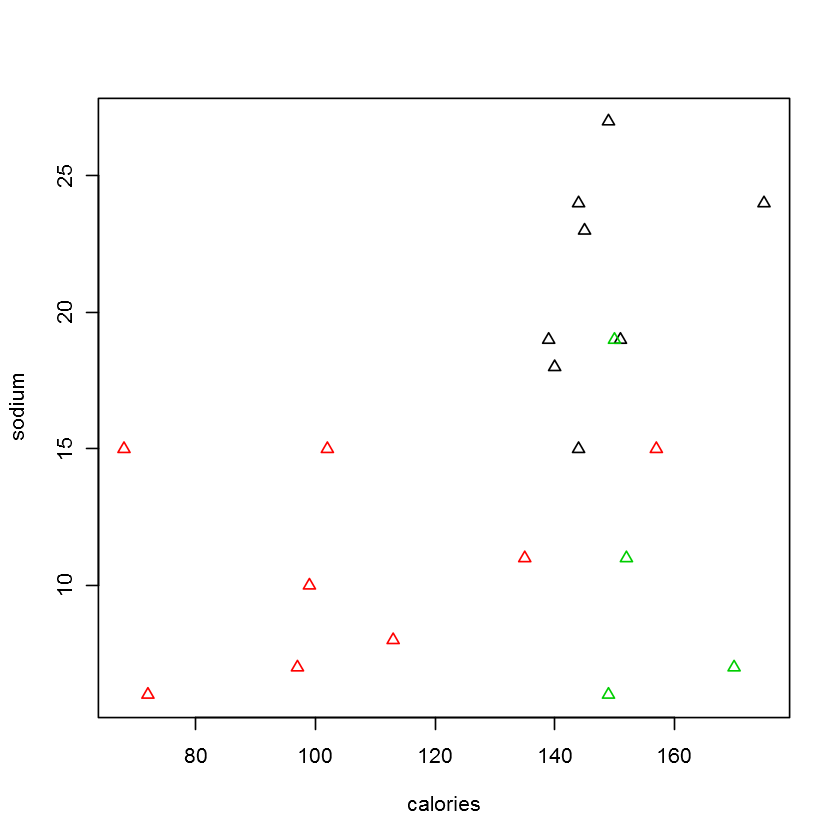

```r
#par(family='STKaiti')#设置字体
plot(x,col=cl$cluster,pch=2,lwd=1) ### 用前两个变量并标注三个类
```

```r
#### 也可以单独展示部分结果####
cl$centers #展示每一类的中心
```

A matrix: 3 × 4 of type dbl

| calories | sodium | alcohol | cost |
| --- | --- | --- | --- |
| 0.5225583 | 0.9382683 | 0.5032520 | -0.6005866 |
| -0.8973473 | -0.6191811 | -0.8410513 | -0.3244548 |
| 0.7495781 | -0.6381744 | 0.6755986 | 1.8500829 |

## 4. 其他算法，以及聚类结果评价-侧影统计量

#### 本例使用iris数据，前4个变量（前4列）依次是花萼长度、花萼宽度、花瓣长度、花瓣宽度四个特征，

第5个变量是类别变量，有3个类别，依次是:山鸢尾、变色鸢尾、维吉尼亚鸢尾。

前4个变量是定量变量，第5个变量是定性变量。下面的代码中提取前四列作为聚类的自变量。

```r
head(iris)  #展示iris数据的5个变量和前几行样本观测值
```

A data.frame: 6 × 5

| Sepal.Length <dbl> | Sepal.Width <dbl> | Petal.Length <dbl> | Petal.Width <dbl> | Species <fct> |
| --- | --- | --- | --- | --- |
| 5.1 | 3.5 | 1.4 | 0.2 | setosa |
| 4.9 | 3.0 | 1.4 | 0.2 | setosa |
| 4.7 | 3.2 | 1.3 | 0.2 | setosa |
| 4.6 | 3.1 | 1.5 | 0.2 | setosa |
| 5.0 | 3.6 | 1.4 | 0.2 | setosa |
| 5.4 | 3.9 | 1.7 | 0.4 | setosa |

### 4.1 k-means对iris进行聚类分析

```r
iris2<-iris[,1:4]
iris.kmeans<-kmeans(iris2,3)
iris.kmeans
```

```
K-means clustering with 3 clusters of sizes 50, 38, 62

Cluster means:
  Sepal.Length Sepal.Width Petal.Length Petal.Width
1     5.006000    3.428000     1.462000    0.246000
2     6.850000    3.073684     5.742105    2.071053
3     5.901613    2.748387     4.393548    1.433871

Clustering vector:
  [1] 1 1 1 1 1 1 1 1 1 1 1 1 1 1 1 1 1 1 1 1 1 1 1 1 1 1 1 1 1 1 1 1 1 1 1 1 1
 [38] 1 1 1 1 1 1 1 1 1 1 1 1 1 3 3 2 3 3 3 3 3 3 3 3 3 3 3 3 3 3 3 3 3 3 3 3 3
 [75] 3 3 3 2 3 3 3 3 3 3 3 3 3 3 3 3 3 3 3 3 3 3 3 3 3 3 2 3 2 2 2 2 3 2 2 2 2
[112] 2 2 3 3 2 2 2 2 3 2 3 2 3 2 2 3 3 2 2 2 2 2 3 2 2 2 2 3 2 2 2 3 2 2 2 3 2
[149] 2 3

Within cluster sum of squares by cluster:
[1] 15.15100 23.87947 39.82097
 (between_SS / total_SS =  88.4 %)

Available components:

[1] "cluster"      "centers"      "totss"        "withinss"     "tot.withinss"
[6] "betweenss"    "size"         "iter"         "ifault"
```

```r
#用table函数查看分类结果情况
table(iris$Species,iris.kmeans$cluster)
```

```
              1  2  3
  setosa     50  0  0
  versicolor  0  2 48
  virginica   0 36 14
```

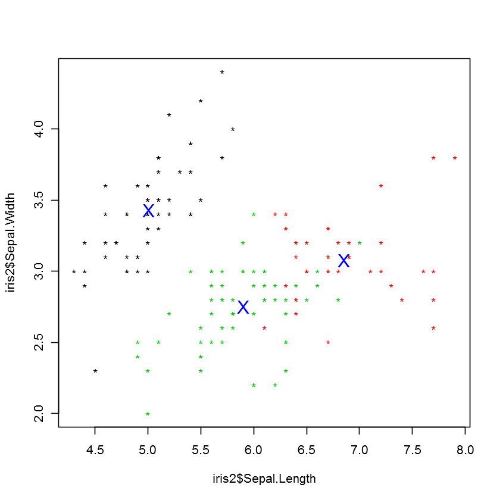

```r
plot(iris2$Sepal.Length,iris2$Sepal.Width,col=iris.kmeans$cluster,pch="*")
points(iris.kmeans$centers,pch="X",cex=1.5,col=4)
```

### 4.2 使用k-mediod方法聚类分析

K-Mediods函数跟Kmeans函数基本类似，不同的是，Kmeans是选择簇中心来表示聚类簇，而K-Mediods选择靠近簇中心的对象来表示聚类簇。在含有离群点的情况，下K-Mediods的鲁棒性（稳定性）要更好。

基于中心点的划分算法PAM是K-Mediods中的经典算法，但是PAM很难扩展到较大数据集上，而Clara算法是对PAM算法的改进，他是在较大数据集中分为几个小数据集，分别进行PAM算法，并返回最好的聚类。因此在处理较大数据集的情况下CLARA算法要优于PAM算法，

在R的cluster包中的PAM和CLARA函数分别实现了上述两个算法，但是这两个函数都需要用户指定k值，即中心点的个数。fpc包中的pamk()函数提供了更加强大的算法，该函数不要求用户输入k值，而是自动调用pam或者clara来根据最优平均阴影宽度来估计聚类簇个数来划分数据集。

```r
data=iris[,1:4]#取数据的前四列
#install.packages("cluster",repos="https://mirror.lzu.edu.cn/CRAN/")
library(cluster)# 加载包
pam3=pam(data,3)#k-mediod聚类方法，pam算法
table(iris$Species,pam3$clustering)
```

```
              1  2  3
  setosa     50  0  0
  versicolor  0 48  2
  virginica   0 14 36
```

```r
pam3$silinfo$avg.width#查看silhouette width均值
```

0.55281901235641

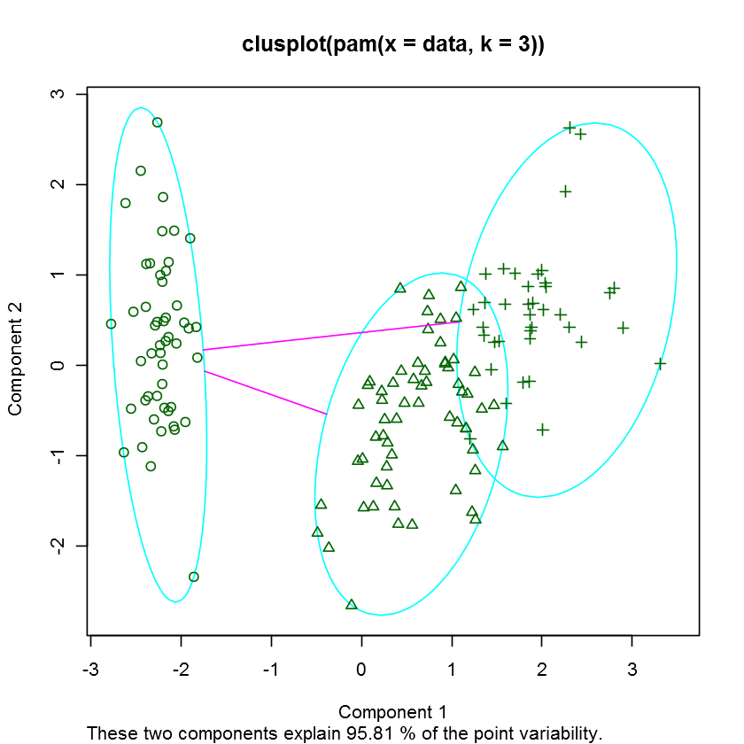

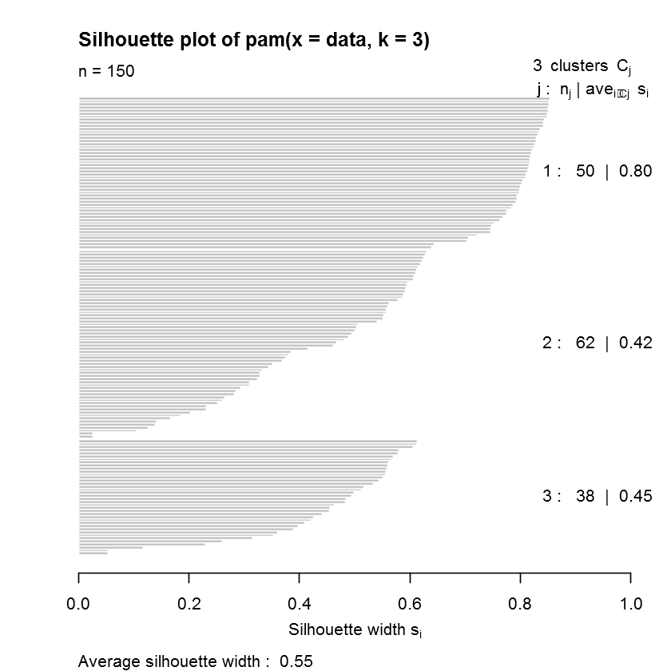

```r
si3=silhouette(pam3)#查看每个silhouette统计量
plot(pam3)#Silhouette　Plot
```

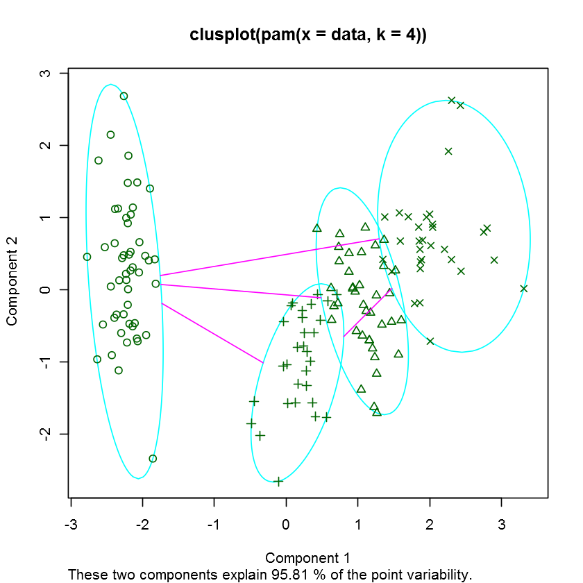

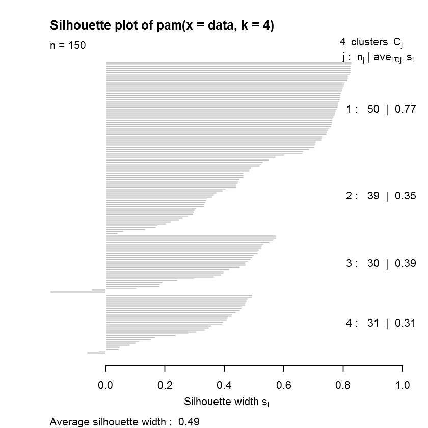

```r
pam4=pam(data,4)
plot(pam4)
```

### 4.3 基于Clara算法的聚类

```
              1  2  3
  setosa     50  0  0
  versicolor  0 48  2
  virginica   0 13 37
```

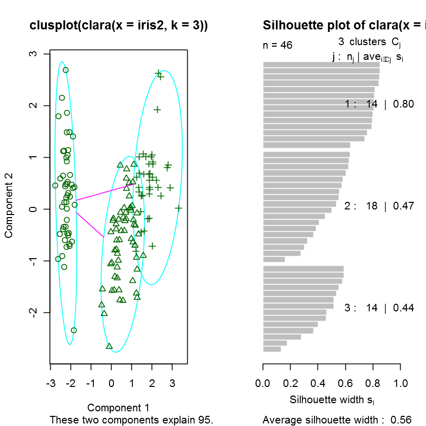

```r
iris2.clara<-clara(iris2,3)
table(iris$Species,iris2.clara$clustering)

#             1  2  3
# setosa     50  0  0
# versicolor  0 48  2
# virginica   0 13 37

layout(matrix(c(1,2),1,2)) #每页显示两个图
plot(iris2.clara)
layout(matrix(1))
```

### 4.4 基于Pamk算法的聚类

```
    setosa versicolor virginica
  1     50          1         0
  2      0         49        50
```

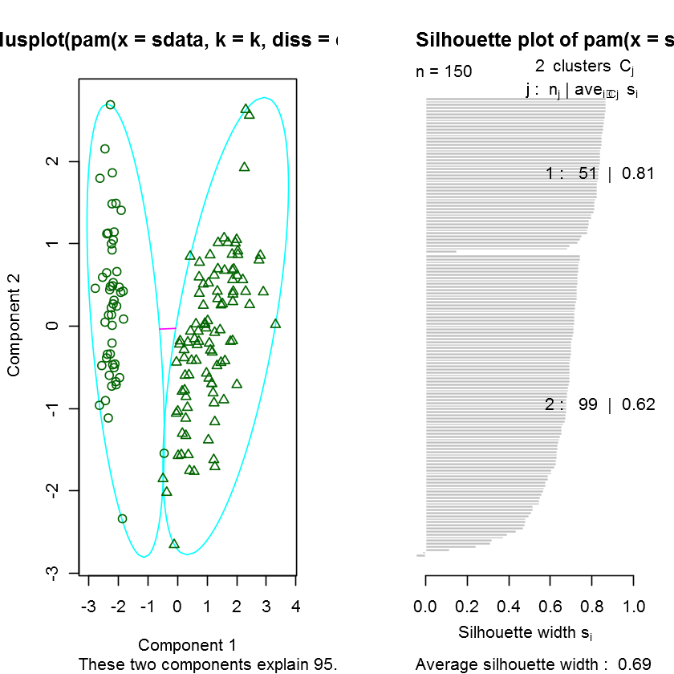

```r
#install.packages("fpc",repos="https://mirror.lzu.edu.cn/CRAN/")
library(fpc)
iris2.pamk<-pamk(iris2)
table(iris2.pamk$pamobject$clustering,iris$Species)


layout(matrix(c(1,2),1,2)) #每页显示两个图
plot(iris2.pamk$pamobject)
layout(matrix(1))

#     setosa versicolor virginica
# 1     50          1         0
# 2      0         49        50

#通过上述分类结果可以看到，pam和calra算法分类结果基本类似，但是pamk将三类分为了两类。。
```

1. 150

2. 5

A data.frame: 40 × 4

|  | Sepal.Length <dbl> | Sepal.Width <dbl> | Petal.Length <dbl> | Petal.Width <dbl> |
| --- | --- | --- | --- | --- |
| 34 | 5.5 | 4.2 | 1.4 | 0.2 |
| 100 | 5.7 | 2.8 | 4.1 | 1.3 |
| 91 | 5.5 | 2.6 | 4.4 | 1.2 |
| 80 | 5.7 | 2.6 | 3.5 | 1.0 |
| 103 | 7.1 | 3.0 | 5.9 | 2.1 |
| 77 | 6.8 | 2.8 | 4.8 | 1.4 |
| 50 | 5.0 | 3.3 | 1.4 | 0.2 |
| 125 | 6.7 | 3.3 | 5.7 | 2.1 |
| 28 | 5.2 | 3.5 | 1.5 | 0.2 |
| 47 | 5.1 | 3.8 | 1.6 | 0.2 |
| 145 | 6.7 | 3.3 | 5.7 | 2.5 |
| 88 | 6.3 | 2.3 | 4.4 | 1.3 |
| 46 | 4.8 | 3.0 | 1.4 | 0.3 |
| 110 | 7.2 | 3.6 | 6.1 | 2.5 |
| 75 | 6.4 | 2.9 | 4.3 | 1.3 |
| 113 | 6.8 | 3.0 | 5.5 | 2.1 |
| 9 | 4.4 | 2.9 | 1.4 | 0.2 |
| 112 | 6.4 | 2.7 | 5.3 | 1.9 |
| 58 | 4.9 | 2.4 | 3.3 | 1.0 |
| 8 | 5.0 | 3.4 | 1.5 | 0.2 |
| 136 | 7.7 | 3.0 | 6.1 | 2.3 |
| 140 | 6.9 | 3.1 | 5.4 | 2.1 |
| 130 | 7.2 | 3.0 | 5.8 | 1.6 |
| 2 | 4.9 | 3.0 | 1.4 | 0.2 |
| 30 | 4.7 | 3.2 | 1.6 | 0.2 |
| 37 | 5.5 | 3.5 | 1.3 | 0.2 |
| 29 | 5.2 | 3.4 | 1.4 | 0.2 |
| 56 | 5.7 | 2.8 | 4.5 | 1.3 |
| 129 | 6.4 | 2.8 | 5.6 | 2.1 |
| 21 | 5.4 | 3.4 | 1.7 | 0.2 |
| 39 | 4.4 | 3.0 | 1.3 | 0.2 |
| 70 | 5.6 | 2.5 | 3.9 | 1.1 |
| 120 | 6.0 | 2.2 | 5.0 | 1.5 |
| 52 | 6.4 | 3.2 | 4.5 | 1.5 |
| 33 | 5.2 | 4.1 | 1.5 | 0.1 |
| 89 | 5.6 | 3.0 | 4.1 | 1.3 |
| 99 | 5.1 | 2.5 | 3.0 | 1.1 |
| 6 | 5.4 | 3.9 | 1.7 | 0.4 |
| 71 | 5.9 | 3.2 | 4.8 | 1.8 |
| 119 | 7.7 | 2.6 | 6.9 | 2.3 |

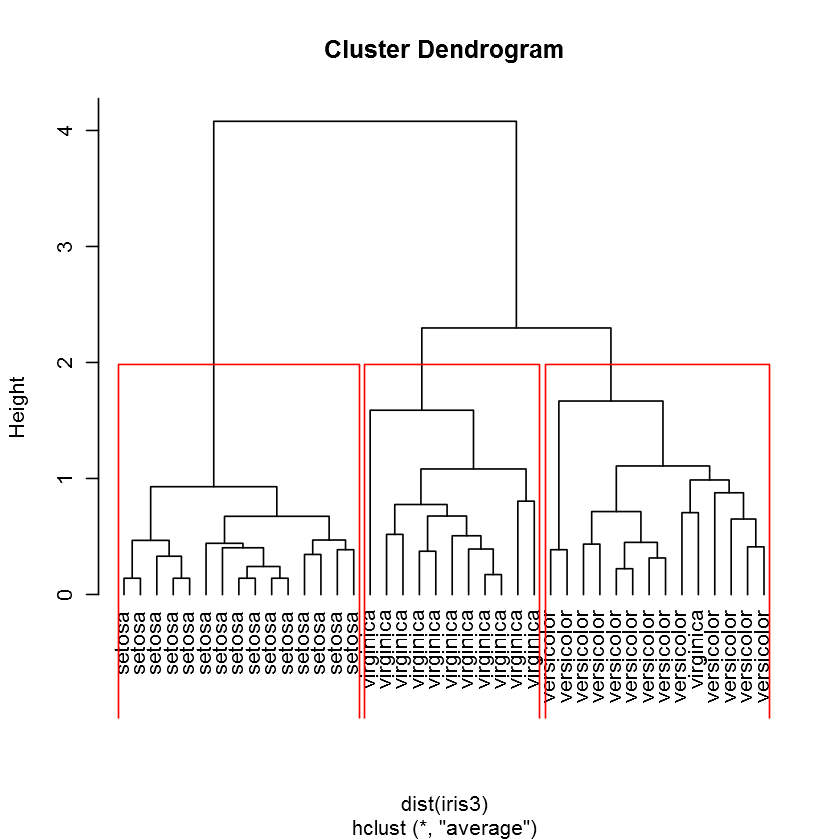

```r
dim(iris)#返回行列数

idx<-sample(1:dim(iris)[1],40)
iris3<-iris[idx,-5]
iris3
hc<-hclust(dist(iris3),method = "ave")  #注意hcluster里边传入的是dist返回值对象

plot(hc,hang=-1,labels=iris$Species[idx])  #这里的hang=-1使得树的节点在下方对齐
#将树分为3块
rect.hclust(hc,k=3)
```

```r
groups<-cutree(hc,k=3)
groups
```

**34**

1

**100**

2

**91**

2

**80**

2

**103**

3

**77**

2

**50**

1

**125**

3

**28**

1

**47**

1

**145**

3

**88**

2

**46**

1

**110**

3

**75**

2

**113**

3

**9**

1

**112**

3

**58**

2

**8**

1

**136**

3

**140**

3

**130**

3

**2**

1

**30**

1

**37**

1

**29**

1

**56**

2

**129**

3

**21**

1

**39**

1

**70**

2

**120**

2

**52**

2

**33**

1

**89**

2

**99**

2

**6**

1

**71**

2

**119**

3

## 5. DBSCAN算法----基于密度的聚类

```
    setosa versicolor virginica
  0      2         10        17
  1     48          0         0
  2      0         37         0
  3      0          3        33
```

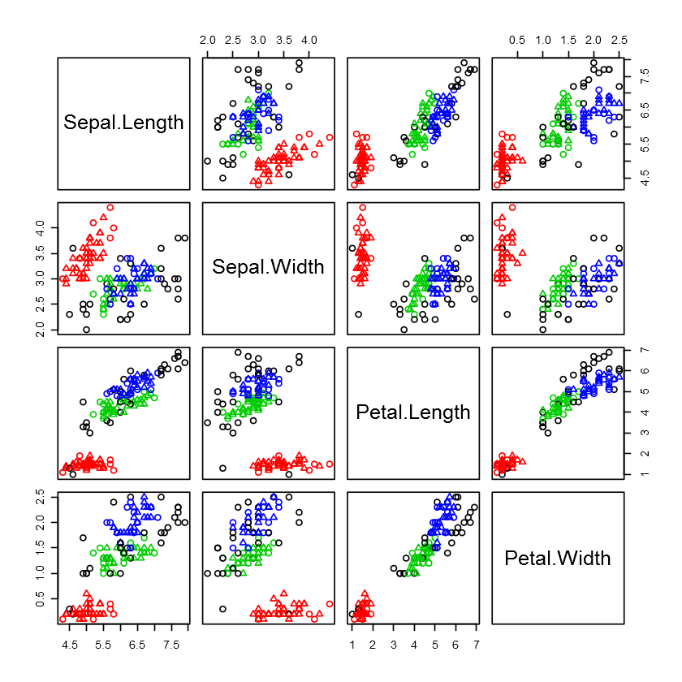

```r
#---基于密度的聚类分析,一种方法通过fpc包中的dbscan实现；另一种方法通过factoextra包实现
library(fpc)
iris2<-iris[-5]
ds<-dbscan(iris2,eps=0.42,MinPts = 5)
table(ds$cluster,iris$Species)

#打印出ds和iris2的聚类散点图
plot(ds,iris2)
```

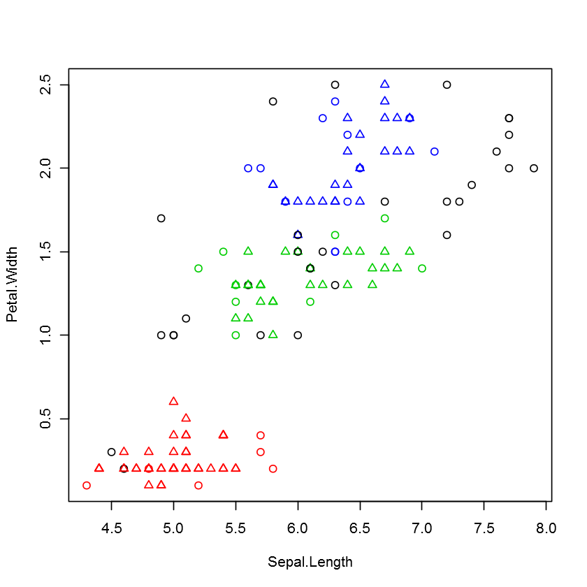

```r
#打印出iris第一列和第四列为坐标轴的聚类结果
plot(ds,iris2[,c(1,4)])
```

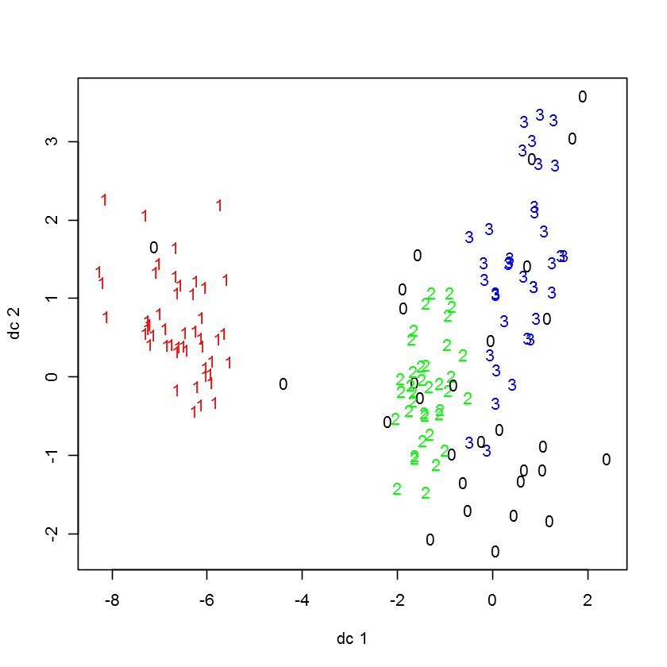

```r
#另一个表示聚类结果的函数，plotcluster
plotcluster(iris2,ds$cluster)
```

#### 我们使用factoextra包中的数据集multishapes进行演示dbscan

该包中的两个函数十分有用，一个用于确定最佳的簇数，一个用于可视化聚类的结果

```r
#install.packages("factoextra",repos="https://mirrors.tongji.edu.cn/CRAN/")
#remove.packages("factoextra")#卸载包
```

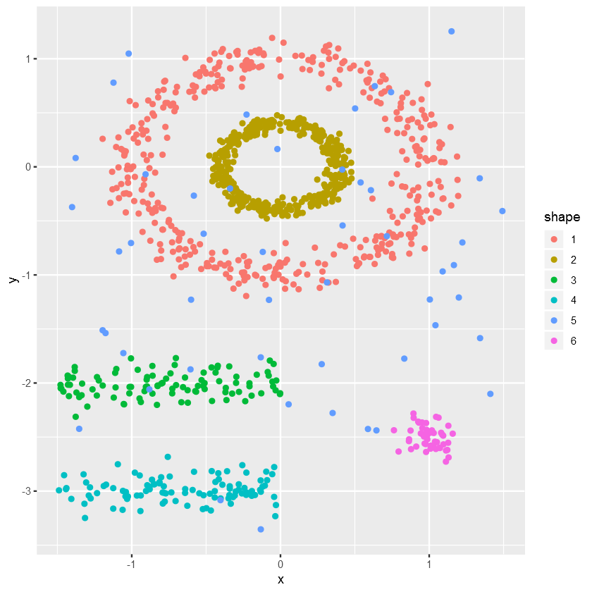

```r
#载入包
library(factoextra)
library(ggplot2)
data("multishapes")
df <- multishapes[, 1:2]
df0<-multishapes
df0$shape<-as.factor(df0$shape)
ggplot(df0,aes(x=x,y=y,colour=shape))+geom_point()
```

```r
#先用k-means算法得到初步聚类
set.seed(123)
km_result <- kmeans(df, 5, nstart = 25)
```

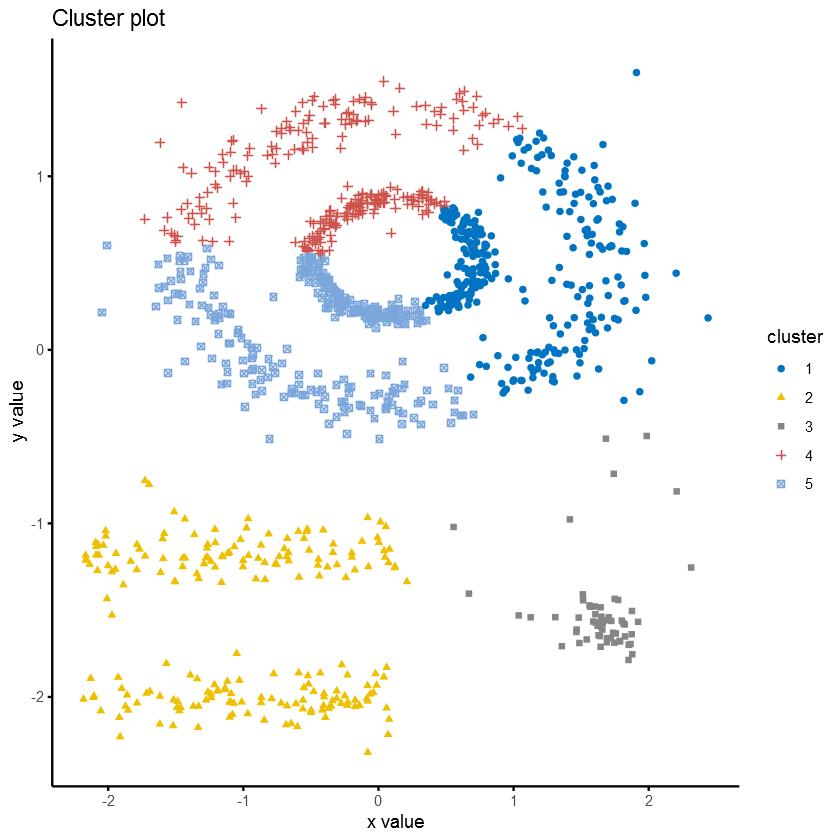

```r
fviz_cluster(km_result , df, geom = "point",
             ellipse= FALSE, show.clust.cent = FALSE,
             palette = "jco", ggtheme = theme_classic())
```

###### 完全不是我们想要的结果。这样我们就回答了第一个问题，为什么需要基于密度的聚类算法，因为像这种奇奇怪怪形状的样本点，我们利用k-means算法根本无法将其进行聚类。那么基于密度的聚类算法为啥可以解决。大家看看这个图，每一类就是一些点密集地连接在一起。密集地也就是代表了密度的不同，所以这里大家就知道了，这个密度不是我们平时说的概率密度分布。实际上是一种样本密度的代表。

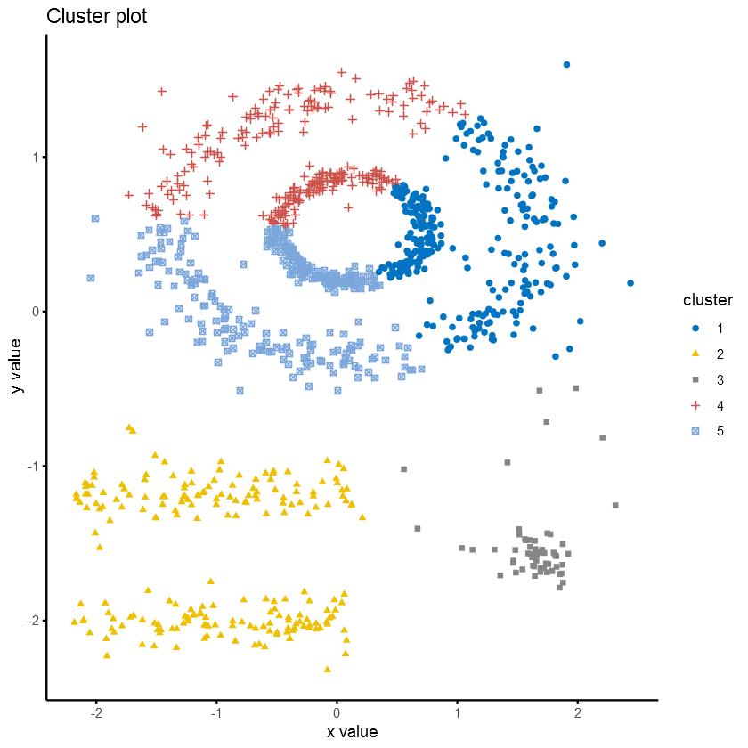

```r
fviz_cluster(km_result , df, geom = "point",
             ellipse= FALSE, show.clust.cent = FALSE,
             palette = "jco", ggtheme = theme_classic())
```

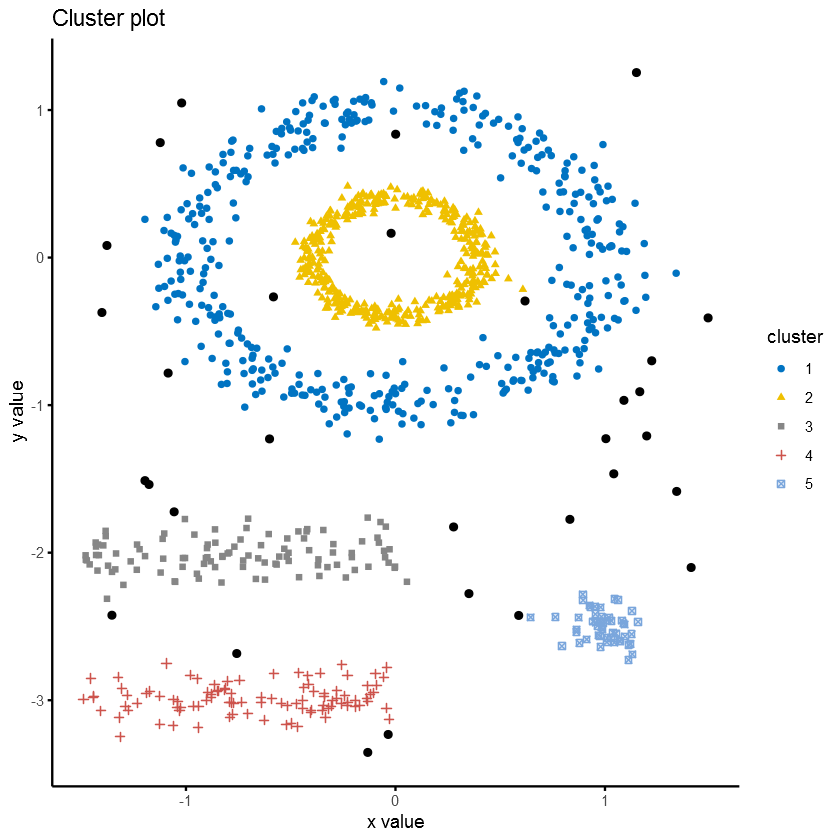

```r
#载入相关包
library("fpc")
#设置随机数种子
set.seed(123)
db <- fpc::dbscan(df, eps = 0.15, MinPts = 5)
fviz_cluster(db, data = df, stand = FALSE,
             ellipse = FALSE, show.clust.cent = FALSE,
             geom = "point",palette = "jco", ggtheme = theme_classic())
```

## 6. EM算法

mclust包提供了利用GMM对数据进行聚类分析的方法。其中函数Mclust()是进行EM聚类的核心函数，它的基本调用格式为：

Mclust(data, G = NULL, modelNames = NULL, prior = NULL, control = emControl(), initialization = NULL, warn = mclust.options("warn"), ...)

其中，data是待处理数据集；G为预设类别数，默认值为1至9，即由软件根据BIC的值在1-9中选择最优值。

## 6.1 举例说明

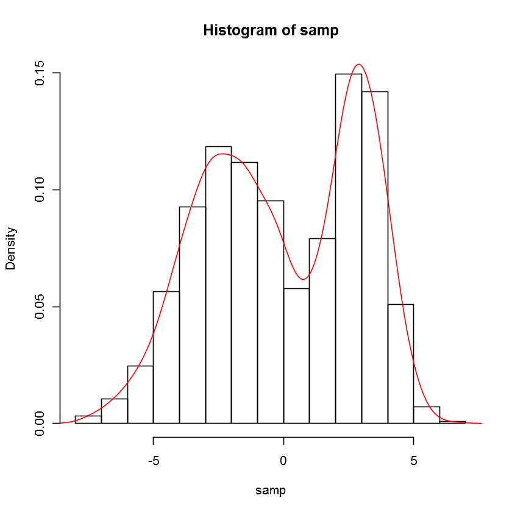

```r
#【模拟样本】指定2个高斯分布的参数，并令其以0.4和0.6的权重随机生成5000个样本
# 生成n=5000的样本samp
set.seed(637351)
n <- 5000

# 权重0.4，高斯参数N(3，1)
alpha1 <- 0.4
miu1   <- 3
sigma1 <- 1

# 权重0.6，高斯参数N(-2，4)
alpha2 <- 0.6
miu2   <- -2
sigma2 <- 2

n1 <- floor(n*alpha1)
n2 <- n-n1

samp <-numeric(n)
samp[1:n1] <- rnorm(n1, miu1, sigma1)
samp[(n1+1):n] <- rnorm(n2, miu2, sigma2)

# 高斯混合模型的密度函数图
hist(samp, freq = FALSE)
lines(density(samp), col = 'red')
```

```r
library(mclust)
mc1 <- Mclust(samp)
summary(mc1, parameters = T)
```

```
----------------------------------------------------
Gaussian finite mixture model fitted by EM algorithm
----------------------------------------------------

Mclust V (univariate, unequal variance) model with 2 components:

 log-likelihood    n df       BIC       ICL
      -11817.81 5000  5 -23678.21 -24140.39

Clustering table:
   1    2
2910 2090

Mixing probabilities:
       1        2
0.594943 0.405057

Means:
        1         2
-2.072087  2.971050

Variances:
        1         2
3.7351318 0.9370625
```

## 6.2 基于EM聚类模型的聚类分析iris数据

```r
head(iris)
```

A data.frame: 6 × 5

| Sepal.Length <dbl> | Sepal.Width <dbl> | Petal.Length <dbl> | Petal.Width <dbl> | Species <fct> |
| --- | --- | --- | --- | --- |
| 5.1 | 3.5 | 1.4 | 0.2 | setosa |
| 4.9 | 3.0 | 1.4 | 0.2 | setosa |
| 4.7 | 3.2 | 1.3 | 0.2 | setosa |
| 4.6 | 3.1 | 1.5 | 0.2 | setosa |
| 5.0 | 3.6 | 1.4 | 0.2 | setosa |
| 5.4 | 3.9 | 1.7 | 0.4 | setosa |

```r
data=iris[,1:4]#取数据的前四列
```

```r
library(mclust)
```

```r
mc<-Mclust(data,3)
summary(mc, parameters = T)
```

```
----------------------------------------------------
Gaussian finite mixture model fitted by EM algorithm
----------------------------------------------------

Mclust VEV (ellipsoidal, equal shape) model with 3 components:

 log-likelihood   n df       BIC       ICL
       -186.074 150 38 -562.5522 -566.4673

Clustering table:
 1  2  3
50 45 55

Mixing probabilities:
        1         2         3
0.3333333 0.3005423 0.3661243

Means:
              [,1]     [,2]     [,3]
Sepal.Length 5.006 5.915044 6.546807
Sepal.Width  3.428 2.777451 2.949613
Petal.Length 1.462 4.204002 5.482252
Petal.Width  0.246 1.298935 1.985523

Variances:
[,,1]
             Sepal.Length Sepal.Width Petal.Length Petal.Width
Sepal.Length   0.13320850  0.10938369  0.019191764 0.011585649
Sepal.Width    0.10938369  0.15495369  0.012096999 0.010010130
Petal.Length   0.01919176  0.01209700  0.028275400 0.005818274
Petal.Width    0.01158565  0.01001013  0.005818274 0.010695632
[,,2]
             Sepal.Length Sepal.Width Petal.Length Petal.Width
Sepal.Length   0.22572159  0.07613348   0.14689934  0.04335826
Sepal.Width    0.07613348  0.08024338   0.07372331  0.03435893
Petal.Length   0.14689934  0.07372331   0.16613979  0.04953078
Petal.Width    0.04335826  0.03435893   0.04953078  0.03338619
[,,3]
             Sepal.Length Sepal.Width Petal.Length Petal.Width
Sepal.Length   0.42943106  0.10784274   0.33452389  0.06538369
Sepal.Width    0.10784274  0.11596343   0.08905176  0.06134034
Petal.Length   0.33452389  0.08905176   0.36422115  0.08706895
Petal.Width    0.06538369  0.06134034   0.08706895  0.08663823
```

```r
table(iris$Species,mc$classification)
```

```
              1  2  3
  setosa     50  0  0
  versicolor  0 45  5
  virginica   0  0 50
```